# ridge_and_lasso_penalty

## CMPINF 2100: Fall 2020

Ridge and lasso penalty with logistic regression and scikit-learn.

## Import modules

```python
import numpy as np
import pandas as pd
import matplotlib.pyplot as plt

import seaborn as sns
```

## Read data

```python
data_url = 'https://raw.githubusercontent.com/jyurko/CMPINF_2100_Fall_2020/master/week_11/week_11_example_data.csv'
df = pd.read_csv(data_url)
```

```python
df.info()
```

```
<class 'pandas.core.frame.DataFrame'>
RangeIndex: 300 entries, 0 to 299
Data columns (total 6 columns):
 #   Column  Non-Null Count  Dtype
---  ------  --------------  -----
 0   x1      300 non-null    float64
 1   x2      300 non-null    float64
 2   x3      300 non-null    float64
 3   x4      300 non-null    float64
 4   x5      300 non-null    object
 5   y       300 non-null    int64
dtypes: float64(4), int64(1), object(1)
memory usage: 14.2+ KB
```

```python
df.y.value_counts()
```

```
0    198
1    102
Name: y, dtype: int64
```

## Fit logistic regression with `statsmodels`

Really, this is fitting by maximizing the likelihood or minimizing the error or minimizing the loss. We are not considering any penalty applied to the coefficients.

```python
import statsmodels.formula.api as smf
```

Fit the most complex model from last week.

```python
fit_10 = smf.logit(formula = 'y ~ x5 * ( np.power(x1,2) + np.power(x2,2) + np.power(x3, 2) + np.power(x4,2) + (x1 + x2 + x3 + x4)**2)', data=df).fit()
```

```
Optimization terminated successfully.
         Current function value: 0.439301
         Iterations 8
```

```python
print( fit_10.summary() )
```

```
                           Logit Regression Results
==============================================================================
Dep. Variable:                      y   No. Observations:                  300
Model:                          Logit   Df Residuals:                      255
Method:                           MLE   Df Model:                           44
Date:                Thu, 05 Nov 2020   Pseudo R-squ.:                  0.3147
Time:                        18:48:38   Log-Likelihood:                -131.79
converged:                       True   LL-Null:                       -192.31
Covariance Type:            nonrobust   LLR p-value:                 4.051e-09
===========================================================================================
                              coef    std err          z      P>|z|      [0.025      0.975]
-------------------------------------------------------------------------------------------
Intercept                   0.7458      0.601      1.240      0.215      -0.433       1.925
x5[T.b]                    -1.1309      0.729     -1.552      0.121      -2.559       0.297
x5[T.c]                     0.4578      0.837      0.547      0.584      -1.183       2.098
np.power(x1, 2)            -1.0743      0.397     -2.709      0.007      -1.852      -0.297
x5[T.b]:np.power(x1, 2)     0.4023      0.499      0.807      0.420      -0.575       1.380
x5[T.c]:np.power(x1, 2)    -0.5093      0.756     -0.674      0.501      -1.991       0.973
np.power(x2, 2)            -0.8350      0.372     -2.243      0.025      -1.565      -0.105
x5[T.b]:np.power(x2, 2)    -0.1107      0.492     -0.225      0.822      -1.076       0.854
x5[T.c]:np.power(x2, 2)     0.0606      0.525      0.116      0.908      -0.968       1.089
np.power(x3, 2)            -0.2713      0.247     -1.097      0.273      -0.756       0.214
x5[T.b]:np.power(x3, 2)     0.2846      0.353      0.806      0.420      -0.407       0.977
x5[T.c]:np.power(x3, 2)    -0.0312      0.461     -0.068      0.946      -0.936       0.873
np.power(x4, 2)             0.1800      0.261      0.689      0.491      -0.332       0.692
x5[T.b]:np.power(x4, 2)    -0.0002      0.304     -0.001      1.000      -0.595       0.595
x5[T.c]:np.power(x4, 2)    -0.2470      0.397     -0.622      0.534      -1.025       0.531
x1                          0.5510      0.476      1.156      0.248      -0.383       1.485
x5[T.b]:x1                  0.3575      0.590      0.606      0.544      -0.799       1.514
x5[T.c]:x1                  0.4010      0.728      0.551      0.582      -1.025       1.827
x2                         -1.3446      0.519     -2.592      0.010      -2.361      -0.328
x5[T.b]:x2                 -0.0390      0.654     -0.060      0.952      -1.321       1.243
x5[T.c]:x2                  0.0915      0.721      0.127      0.899      -1.322       1.505
x3                         -0.0742      0.348     -0.213      0.831      -0.756       0.607
x5[T.b]:x3                  0.9801      0.459      2.136      0.033       0.081       1.879
x5[T.c]:x3                 -0.3483      0.562     -0.620      0.535      -1.449       0.753
x4                         -0.2077      0.347     -0.598      0.550      -0.888       0.473
x5[T.b]:x4                  0.3082      0.413      0.746      0.456      -0.502       1.118
x5[T.c]:x4                  0.3751      0.562      0.667      0.505      -0.727       1.477
x1:x2                      -0.6368      0.757     -0.841      0.400      -2.120       0.847
x5[T.b]:x1:x2               1.5896      0.850      1.870      0.061      -0.076       3.255
x5[T.c]:x1:x2              -0.8419      1.108     -0.760      0.447      -3.013       1.329
x1:x3                      -0.2280      0.414     -0.551      0.582      -1.039       0.583
x5[T.b]:x1:x3              -0.0768      0.554     -0.138      0.890      -1.163       1.010
x5[T.c]:x1:x3               1.0998      0.677      1.624      0.104      -0.228       2.427
x1:x4                       0.2678      0.416      0.644      0.520      -0.548       1.083
x5[T.b]:x1:x4              -0.7687      0.507     -1.515      0.130      -1.763       0.226
x5[T.c]:x1:x4               0.5342      0.805      0.663      0.507      -1.044       2.112
x2:x3                      -0.3215      0.630     -0.511      0.610      -1.556       0.913
x5[T.b]:x2:x3               1.0377      0.714      1.454      0.146      -0.361       2.436
x5[T.c]:x2:x3               0.3386      0.811      0.418      0.676      -1.250       1.927
x2:x4                      -0.1535      0.503     -0.305      0.760      -1.140       0.833
x5[T.b]:x2:x4               0.3072      0.576      0.533      0.594      -0.822       1.437
x5[T.c]:x2:x4              -0.1209      0.713     -0.170      0.865      -1.518       1.277
x3:x4                       0.0984      0.408      0.241      0.809      -0.701       0.898
x5[T.b]:x3:x4              -0.2068      0.503     -0.411      0.681      -1.193       0.779
x5[T.c]:x3:x4               0.0692      0.626      0.111      0.912      -1.158       1.297
===========================================================================================
```

## Fit with `sklearn`

```python
from patsy import dmatrices
from sklearn.linear_model import LogisticRegression
```

Create the response and input feature array for `sklearn`, what is different between the input feature array required from `statsmodels`? Tell `dmatrices()` to **NOT** include the intercept column of 1's in the input feature array by including `-1` in the formula. Notice this gives us the ONE-HOT-ENCODING formulation of the categorical variable.

```python
y_sk, X_sk = dmatrices('y ~ x5 * ( np.power(x1,2) + np.power(x2,2) + np.power(x3,2) + np.power(x4,2) + (x1 + x2 + x3 + x4)**2 ) - 1', data=df)
```

```python
X_sk.shape
```

```
(300, 45)
```

```python
print( type(y_sk) )

print( y_sk.shape )

print( y_sk.ndim )

### turn y_sk from a 2D NumPy array into a 1D NumPy array
print( y_sk.ravel().shape )
```

```
<class 'patsy.design_info.DesignMatrix'>
(300, 1)
2
(300,)
```

```python
y_check, X_check = dmatrices('y ~ x5 * ( np.power(x1,2) + np.power(x2,2) + np.power(x3,2) + np.power(x4,2) + (x1 + x2 + x3 + x4)**2 ) - 1', data=df, return_type='dataframe')
```

```python
X_check.info()
```

```
<class 'pandas.core.frame.DataFrame'>
Int64Index: 300 entries, 0 to 299
Data columns (total 45 columns):
 #   Column                   Non-Null Count  Dtype
---  ------                   --------------  -----
 0   x5[a]                    300 non-null    float64
 1   x5[b]                    300 non-null    float64
 2   x5[c]                    300 non-null    float64
 3   np.power(x1, 2)          300 non-null    float64
 4   x5[T.b]:np.power(x1, 2)  300 non-null    float64
 5   x5[T.c]:np.power(x1, 2)  300 non-null    float64
 6   np.power(x2, 2)          300 non-null    float64
 7   x5[T.b]:np.power(x2, 2)  300 non-null    float64
 8   x5[T.c]:np.power(x2, 2)  300 non-null    float64
 9   np.power(x3, 2)          300 non-null    float64
```

[output cut: 37 more lines]

```python
X_check.head()
```

|  | x5[a] | x5[b] | x5[c] | np.power(x1, 2) | x5[T.b]:np.power(x1, 2) | x5[T.c]:np.power(x1, 2) | np.power(x2, 2) | x5[T.b]:np.power(x2, 2) | x5[T.c]:np.power(x2, 2) | np.power(x3, 2) | ... | x5[T.c]:x1:x4 | x2:x3 | x5[T.b]:x2:x3 | x5[T.c]:x2:x3 | x2:x4 | x5[T.b]:x2:x4 | x5[T.c]:x2:x4 | x3:x4 | x5[T.b]:x3:x4 | x5[T.c]:x3:x4 |
| --- | --- | --- | --- | --- | --- | --- | --- | --- | --- | --- | --- | --- | --- | --- | --- | --- | --- | --- | --- | --- | --- |
| 0 | 0.0 | 0.0 | 1.0 | 1.160817 | 0.000000 | 1.160817 | 0.982267 | 0.000000 | 0.982267 | 0.043518 | ... | -1.098685 | -0.206752 | -0.000000 | -0.206752 | 1.010662 | 0.000000 | 1.010662 | -0.212729 | -0.000000 | -0.212729 |
| 1 | 0.0 | 1.0 | 0.0 | 0.406722 | 0.406722 | 0.000000 | 0.094560 | 0.094560 | 0.000000 | 3.219334 | ... | -0.000000 | 0.551743 | 0.551743 | 0.000000 | -0.365930 | -0.365930 | -0.000000 | -2.135145 | -2.135145 | -0.000000 |
| 2 | 0.0 | 1.0 | 0.0 | 1.809411 | 1.809411 | 0.000000 | 1.156228 | 1.156228 | 0.000000 | 2.839372 | ... | 0.000000 | -1.811895 | -1.811895 | -0.000000 | -0.180517 | -0.180517 | -0.000000 | 0.282884 | 0.282884 | 0.000000 |
| 3 | 0.0 | 1.0 | 0.0 | 2.755346 | 2.755346 | 0.000000 | 0.540454 | 0.540454 | 0.000000 | 0.044328 | ... | -0.000000 | -0.154781 | -0.154781 | -0.000000 | -1.862962 | -1.862962 | -0.000000 | 0.533533 | 0.533533 | 0.000000 |
| 4 | 0.0 | 1.0 | 0.0 | 1.398018 | 1.398018 | 0.000000 | 2.557249 | 2.557249 | 0.000000 | 0.091201 | ... | 0.000000 | -0.482932 | -0.482932 | -0.000000 | 1.929599 | 1.929599 | 0.000000 | -0.364401 | -0.364401 | -0.000000 |

5 rows × 45 columns

### Maximum Likelihood Estimates (MLEs)

First, let's recover the behavior of the `statsmodels` result. This will require that we specify the `penalty` argument to be `'none'`.

```python
sk_mle = LogisticRegression(penalty='none', solver='lbfgs', max_iter=5001, fit_intercept=False).fit(X_sk, y_sk.ravel())
```

Check our coefficient estimates between the `statsmodels` version and the `sklearn` version with `penalty='none'`.

```python
### access the coefficient estimates

print( type(sk_mle.coef_) )
print( sk_mle.coef_.shape )
```

```
<class 'numpy.ndarray'>
(1, 45)
```

```python
pd.DataFrame({'statsmodels': list(fit_10.params),
             'sklearn_none': list(sk_mle.coef_.ravel())})
```

|  | statsmodels | sklearn_none |
| --- | --- | --- |
| 0 | 0.745848 | 0.745668 |
| 1 | -1.130891 | -0.385047 |
| 2 | 0.457841 | 1.203648 |
| 3 | -1.074338 | -1.074234 |
| 4 | 0.402314 | 0.402282 |
| 5 | -0.509309 | -0.509662 |
| 6 | -0.835012 | -0.835028 |
| 7 | -0.110747 | -0.110721 |
| 8 | 0.060637 | 0.060735 |
| 9 | -0.271307 | -0.271293 |
| 10 | 0.284589 | 0.284556 |
| 11 | -0.031187 | -0.031358 |
| 12 | 0.180032 | 0.180082 |
| 13 | -0.000157 | -0.000202 |
| 14 | -0.246957 | -0.246894 |
| 15 | 0.550972 | 0.550777 |
| 16 | 0.357494 | 0.357599 |
| 17 | 0.401011 | 0.401345 |
| 18 | -1.344587 | -1.344532 |
| 19 | -0.039016 | -0.039029 |
| 20 | 0.091459 | 0.091337 |
| 21 | -0.074242 | -0.074240 |
| 22 | 0.980051 | 0.980028 |
| 23 | -0.348263 | -0.348396 |
| 24 | -0.207680 | -0.207508 |
| 25 | 0.308241 | 0.308017 |
| 26 | 0.375129 | 0.375018 |
| 27 | -0.636838 | -0.637185 |
| 28 | 1.589596 | 1.589852 |
| 29 | -0.841923 | -0.841631 |
| 30 | -0.227950 | -0.228125 |
| 31 | -0.076753 | -0.076567 |
| 32 | 1.099760 | 1.100243 |
| 33 | 0.267787 | 0.267579 |
| 34 | -0.768738 | -0.768438 |
| 35 | 0.534197 | 0.534747 |
| 36 | -0.321506 | -0.321794 |
| 37 | 1.037686 | 1.038000 |
| 38 | 0.338556 | 0.338824 |
| 39 | -0.153466 | -0.153259 |
| 40 | 0.307197 | 0.306935 |
| 41 | -0.120883 | -0.120948 |
| 42 | 0.098378 | 0.098592 |
| 43 | -0.206761 | -0.206986 |
| 44 | 0.069240 | 0.068941 |

## Calculate Accuracy

```python
print( sk_mle.score(X_sk, y_sk.ravel()) )
```

```
0.76
```

## Regularization - Ridge Penalty

The Ridge or the L2-norm is equal to the sum of the squared coefficients in the model. The inverse of the regularization strength is a multiplier that controls the "importance" of the penalty term. The default value is `C=1`.

```python
sk_ridge_default_c = LogisticRegression(penalty='l2', solver='lbfgs', C=1.0, max_iter=5001, fit_intercept=False).fit(X_sk, y_sk.ravel())
```

Let's now try extreme values for the `C` parameter. We will consider a very large value, `C=10000`, and a very small value with `C=0.0001`.

```python
sk_ridge_large_c = LogisticRegression(penalty='l2', solver='lbfgs', C=10000, max_iter=5001, fit_intercept=False).fit(X_sk, y_sk.ravel())
```

```python
sk_ridge_small_c = LogisticRegression(penalty='l2', solver='lbfgs', C=0.0001, max_iter=5001, fit_intercept=False).fit(X_sk, y_sk.ravel())
```

Compare the coefficient estimates between the 3 different Ridge Penalties and the Maximum Likelihood Estimates.

```python
pd.DataFrame({'statsmodels': list(fit_10.params),
             'sklearn_none': list(sk_mle.coef_.ravel()),
             'ridge_large_C': list(sk_ridge_large_c.coef_.ravel()),
             'ridge_default_C': list(sk_ridge_default_c.coef_.ravel()),
             'ridge_small_C': list(sk_ridge_small_c.coef_.ravel())})
```

|  | statsmodels | sklearn_none | ridge_large_C | ridge_default_C | ridge_small_C |
| --- | --- | --- | --- | --- | --- |
| 0 | 0.745848 | 0.745668 | 0.745550 | 0.433713 | -0.000895 |
| 1 | -1.130891 | -0.385047 | -0.385085 | -0.338735 | -0.003048 |
| 2 | 0.457841 | 1.203648 | 1.204070 | 0.810038 | -0.000588 |
| 3 | -1.074338 | -1.074234 | -1.074137 | -0.810828 | -0.008452 |
| 4 | 0.402314 | 0.402282 | 0.402104 | 0.173079 | -0.003862 |
| 5 | -0.509309 | -0.509662 | -0.510029 | -0.282306 | -0.001864 |
| 6 | -0.835012 | -0.835028 | -0.835053 | -0.586107 | -0.007527 |
| 7 | -0.110747 | -0.110721 | -0.110683 | -0.231738 | -0.004516 |
| 8 | 0.060637 | 0.060735 | 0.060621 | -0.085639 | -0.001907 |
| 9 | -0.271307 | -0.271293 | -0.271302 | -0.188621 | -0.006391 |
| 10 | 0.284589 | 0.284556 | 0.284634 | 0.198223 | -0.002633 |
| 11 | -0.031187 | -0.031358 | -0.031412 | 0.023083 | -0.000926 |
| 12 | 0.180032 | 0.180082 | 0.180146 | 0.194123 | -0.003247 |
| 13 | -0.000157 | -0.000202 | -0.000284 | -0.028338 | -0.002488 |
| 14 | -0.246957 | -0.246894 | -0.247121 | -0.238705 | -0.001019 |
| 15 | 0.550972 | 0.550777 | 0.550492 | 0.507425 | 0.002058 |
| 16 | 0.357494 | 0.357599 | 0.358034 | 0.235042 | 0.000719 |
| 17 | 0.401011 | 0.401345 | 0.401593 | 0.298681 | 0.001181 |
| 18 | -1.344587 | -1.344532 | -1.344545 | -1.071252 | -0.003636 |
| 19 | -0.039016 | -0.039029 | -0.039082 | -0.123611 | -0.001446 |
| 20 | 0.091459 | 0.091337 | 0.091357 | -0.098983 | -0.001490 |
| 21 | -0.074242 | -0.074240 | -0.074501 | -0.004361 | 0.001104 |
| 22 | 0.980051 | 0.980028 | 0.980323 | 0.765847 | 0.001377 |
| 23 | -0.348263 | -0.348396 | -0.347938 | -0.317579 | -0.000032 |
| 24 | -0.207680 | -0.207508 | -0.207402 | -0.123763 | -0.000189 |
| 25 | 0.308241 | 0.308017 | 0.307980 | 0.173946 | -0.000387 |
| 26 | 0.375129 | 0.375018 | 0.374627 | 0.223986 | 0.000277 |
| 27 | -0.636838 | -0.637185 | -0.637382 | -0.219265 | -0.000405 |
| 28 | 1.589596 | 1.589852 | 1.590159 | 0.956608 | 0.000271 |
| 29 | -0.841923 | -0.841631 | -0.841971 | -0.712795 | -0.000377 |
| 30 | -0.227950 | -0.228125 | -0.228510 | -0.082761 | -0.000149 |
| 31 | -0.076753 | -0.076567 | -0.076042 | -0.130761 | 0.000105 |
| 32 | 1.099760 | 1.100243 | 1.100815 | 0.604196 | 0.000053 |
| 33 | 0.267787 | 0.267579 | 0.267464 | 0.168509 | -0.000139 |
| 34 | -0.768738 | -0.768438 | -0.768434 | -0.595294 | -0.000403 |
| 35 | 0.534197 | 0.534747 | 0.535069 | 0.256380 | -0.000061 |
| 36 | -0.321506 | -0.321794 | -0.321851 | 0.020130 | 0.001336 |
| 37 | 1.037686 | 1.038000 | 1.037965 | 0.548286 | 0.001152 |
| 38 | 0.338556 | 0.338824 | 0.339116 | -0.108071 | -0.000308 |
| 39 | -0.153466 | -0.153259 | -0.153017 | -0.133202 | -0.000191 |
| 40 | 0.307197 | 0.306935 | 0.306732 | 0.215776 | -0.000268 |
| 41 | -0.120883 | -0.120948 | -0.121558 | -0.073159 | -0.000010 |
| 42 | 0.098378 | 0.098592 | 0.098761 | 0.115182 | 0.001509 |
| 43 | -0.206761 | -0.206986 | -0.207079 | -0.168834 | -0.000095 |
| 44 | 0.069240 | 0.068941 | 0.068456 | 0.110550 | 0.000885 |

### Calculate Accuracy of the Ridge models

```python
print( sk_ridge_large_c.score(X_sk, y_sk.ravel()) )

print( sk_ridge_default_c.score(X_sk, y_sk.ravel()) )

print( sk_ridge_small_c.score(X_sk, y_sk.ravel()) )
```

```
0.76
0.7666666666666667
0.66
```

```python
df.y.value_counts()
```

```
0    198
1    102
Name: y, dtype: int64
```

```python
df.y.sum() / df.shape[0]
```

```
0.34
```

```python
df.y.mean()
```

```
0.34
```

```python
1 - df.y.mean()
```

```
0.6599999999999999
```

### What value of `C` should we use?

Data splitting or **RESAMPLING**. We will break up the data multiple times. Into several different **training** and **hold-out** (validation) test sets.

https://scikit-learn.org/stable/modules/cross_validation.html#cross-validation

```python
from sklearn.model_selection import KFold
```

We will use 5-fold cross validation. Which breaks up the data 5 times. Each fold consists of a training set with 80% of the data, and the remaining 20% are used for testing/validation.

```python
kf05 = KFold(n_splits=5, shuffle=True, random_state=101)
```

```python
kf05.get_n_splits(X_sk)
```

```
5
```

If we call the `.split()` method to break up the data set...

```python
kf05.split(X_sk)
```

```
<generator object _BaseKFold.split at 0x000001B984623510>
```

Let's apply the `KFold()` generator and examine the training/testing split sizes.

```python
# initialize some lists

x_train_list = []
y_train_list = []

x_test_list = []
y_test_list = []

# iterate over the folds using the generator
for train_id, test_id in kf05.split(X_sk):
    x_train_list.append(X_sk[train_id])
    y_train_list.append(y_sk[train_id])

    x_test_list.append(X_sk[test_id])
    y_test_list.append(y_sk[test_id])
```

Check the length of the lists to see that they have the same number of elements as the `n_splits` argument to `KFold()`.

```python
len( x_train_list )
```

```
5
```

```python
len( x_test_list )
```

```
5
```

```python
print( x_train_list[0].shape )
```

```
(240, 45)
```

```python
print( x_test_list[0].shape )
```

```
(60, 45)
```

Total number of rows in the data set.

```python
print( X_sk.shape )
```

```
(300, 45)
```

Visualize the random selection of the data points per fold.

```python
### create a visualization to show which points were selected in which fold
fold_id_list = []

for ii, (tr, tt) in enumerate(kf05.split(X_sk)):
    # initialize a list
    index_type = np.array([np.nan] * X_sk.shape[0])
    index_type[tt] = 1
    index_type[tr] = 0
    index_df = pd.DataFrame({'observation_id': list(range(X_sk.shape[0])),
                            'observation_type': pd.Series(index_type)})

    index_df['fold_id'] = ii

    fold_id_list.append(index_df)
```

```python
fold_id_info = pd.concat(fold_id_list)
```

```python
### reshape the data from long-format to wide-format in order to help create a
### heatmap within Seaborn
fold_id_info['observation_usage'] = np.where(fold_id_info.observation_type == 1, 'test', 'train')
five_fold = fold_id_info.loc[:, ['observation_id', 'fold_id', 'observation_type']].pivot(columns='fold_id', values='observation_type')
```

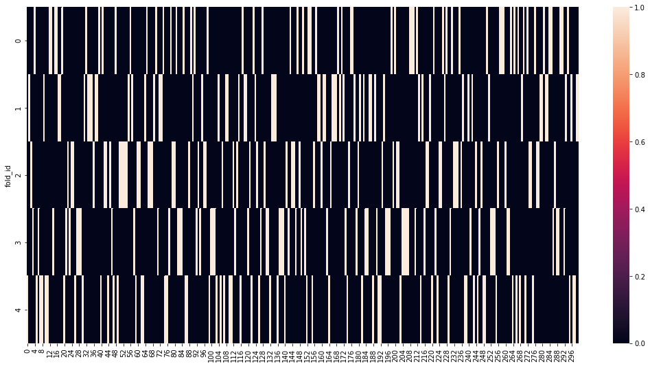

```python
fig, ax = plt.subplots(figsize=(18, 9))

sns.heatmap(five_fold.T)

plt.show()
```

### Execute K-fold cross validation

```python
def evaluate_model_with_cv(cv, X, y, mod):
    train_res = []
    test_res = []

    for train_id, test_id in cv.split(X):
        X_train, X_test = X[train_id], X[test_id]
        y_train, y_test = y[train_id], y[test_id]

        mod_fit = mod.fit(X_train, y_train.ravel())

        train_res.append( mod_fit.score(X_train, y_train.ravel()) )
        test_res.append( mod_fit.score(X_test, y_test.ravel()) )

    return (train_res, test_res)
```

Initialize a model object, first consider the default value for `C`.

```python
ridge_default = LogisticRegression(penalty='l2', solver='lbfgs', C=1.0, max_iter=5001, fit_intercept=False)
```

Evaluate the training and test set accuracy using the default model.

```python
train_cv_results_default, test_cv_results_default = evaluate_model_with_cv(kf05, X_sk, y_sk, ridge_default)
```

```python
train_cv_results_default
```

```
[0.7916666666666666,
 0.7541666666666667,
 0.8041666666666667,
 0.7833333333333333,
 0.775]
```

```python
test_cv_results_default
```

```
[0.6,
 0.6666666666666666,
 0.6666666666666666,
 0.7166666666666667,
 0.7166666666666667]
```

Repeat the 5-fold cross-validation on the large `C` value ridge model.

```python
ridge_large_c = LogisticRegression(penalty='l2', solver='lbfgs', C=10000, max_iter=5001, fit_intercept=False)
```

```python
train_cv_results_large_c, test_cv_results_large_c = evaluate_model_with_cv(kf05, X_sk, y_sk, ridge_large_c)
```

```python
train_cv_results_large_c
```

```
[0.8041666666666667,
 0.7666666666666667,
 0.8041666666666667,
 0.7833333333333333,
 0.7666666666666667]
```

```python
test_cv_results_large_c
```

```
[0.5833333333333334,
 0.6666666666666666,
 0.6,
 0.6833333333333333,
 0.7166666666666667]
```

Repeat the 5-fold cross-validation on the small `C` value ridge model.

```python
ridge_small_c = LogisticRegression(penalty='l2', solver='lbfgs', C=0.0001, max_iter=5001, fit_intercept=False)
```

```python
train_cv_results_small_c, test_cv_results_small_c = evaluate_model_with_cv(kf05, X_sk, y_sk, ridge_small_c)
```

Compare the results on the training sets.

```python
print( train_cv_results_default )

print( train_cv_results_large_c )

print( train_cv_results_small_c )
```

```
[0.7916666666666666, 0.7541666666666667, 0.8041666666666667, 0.7833333333333333, 0.775]
[0.8041666666666667, 0.7666666666666667, 0.8041666666666667, 0.7833333333333333, 0.7666666666666667]
[0.6625, 0.6625, 0.6666666666666666, 0.6541666666666667, 0.6541666666666667]
```

```python
print( np.mean(train_cv_results_default) )

print( np.mean(train_cv_results_large_c) )

print( np.mean(train_cv_results_small_c) )
```

```
0.7816666666666666
0.7849999999999999
0.66
```

Compare the results on the TEST SETS.

```python
print( np.mean(test_cv_results_default) )

print( np.mean(test_cv_results_large_c) )

print( np.mean(test_cv_results_small_c) )
```

```
0.6733333333333333
0.65
0.6599999999999999
```

## Built in cross-validation functions

`sklearn` provides a handful of different cross-validation functions for you to use.

```python
from sklearn.model_selection import cross_val_score
```

```python
test_accuracy_default = cross_val_score(ridge_default, X_sk, y_sk.ravel(), cv=kf05)
```

Compare with our home made version.

```python
print( test_cv_results_default )
```

```
[0.6, 0.6666666666666666, 0.6666666666666666, 0.7166666666666667, 0.7166666666666667]
```

```python
print( test_accuracy_default )
```

```
[0.6        0.66666667 0.66666667 0.71666667 0.71666667]
```

```python
type( test_accuracy_default )
```

```
numpy.ndarray
```

```python
print( test_accuracy_default.mean() )
```

```
0.6733333333333333
```

```python
test_accuracy_large_c = cross_val_score(ridge_large_c, X_sk, y_sk.ravel(), cv=kf05)
```

```python
print( test_cv_results_large_c )

print( test_accuracy_large_c )
```

```
[0.5833333333333334, 0.6666666666666666, 0.6, 0.6833333333333333, 0.7166666666666667]
[0.58333333 0.66666667 0.6        0.68333333 0.71666667]
```

```python
test_accuracy_small_c = cross_val_score(ridge_small_c, X_sk, y_sk.ravel(), cv=kf05)
```

```python
print( test_cv_results_small_c )

print( test_accuracy_small_c )
```

```
[0.65, 0.65, 0.6333333333333333, 0.6833333333333333, 0.6833333333333333]
[0.65       0.65       0.63333333 0.68333333 0.68333333]
```

## Find the optimal value of `C`

Try out many different values of `C` in order to find the best or optimal value.

```python
from sklearn.linear_model import LogisticRegressionCV
```

```python
ridge_tune_results = LogisticRegressionCV(penalty='l2', Cs=101, cv=kf05, solver='lbfgs', max_iter=5001, fit_intercept=False).fit(X_sk, y_sk.ravel())
```

Check the methods and attributes associated with the object.

```python
dir( ridge_tune_results )
```

```
['C_',
 'Cs',
 'Cs_',
 '__class__',
 '__delattr__',
 '__dict__',
 '__dir__',
 '__doc__',
 '__eq__',
 '__format__',
 '__ge__',
 '__getattribute__',
 '__getstate__',
 '__gt__',
 '__hash__',
 '__init__',
 '__init_subclass__',
 '__le__',
 '__lt__',
 '__module__',
 '__ne__',
 '__new__',
 '__reduce__',
 '__reduce_ex__',
 '__repr__',
 '__setattr__',
 '__setstate__',
 '__sizeof__',
 '__str__',
 '__subclasshook__',
 '__weakref__',
 '_check_n_features',
 '_estimator_type',
 '_get_param_names',
 '_get_tags',
 '_more_tags',
 '_predict_proba_lr',
 '_repr_html_',
 '_repr_html_inner',
 '_repr_mimebundle_',
```

[output cut: 21 more lines]

```
 'n_jobs',
 'penalty',
 'predict',
 'predict_log_proba',
 'predict_proba',
 'random_state',
 'refit',
 'score',
 'scores_',
 'scoring',
 'set_params',
 'solver',
 'sparsify',
 'tol',
 'verbose']
```

The identified optimal value for `C`:

```python
ridge_tune_results.C_
```

```
array([0.02511886])
```

Let's visualize the model performance across the different folds.

```python
type( ridge_tune_results.scores_ )
```

```
dict
```

```python
ridge_tune_results.scores_.keys()
```

```
dict_keys([1.0])
```

```python
ridge_tune_results.scores_[1.0].shape
```

```
(5, 101)
```

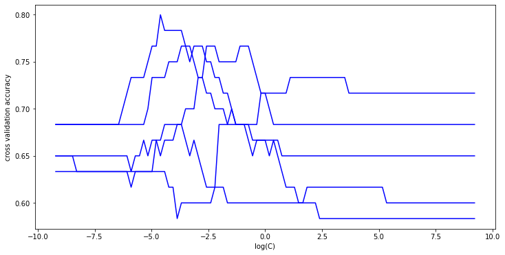

```python
fig, ax = plt.subplots(figsize=(12,6))

ax.plot(np.log(ridge_tune_results.Cs_), ridge_tune_results.scores_[1.0].T, 'b-')
ax.set_xlabel('log(C)')
ax.set_ylabel('cross validation accuracy')

plt.show()
```

We choose the best value of `C` based on the AVERAGE behavior across the folds.

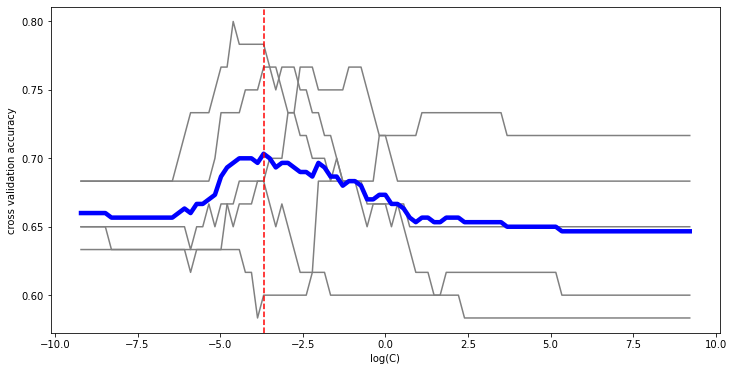

```python
fig, ax = plt.subplots(figsize=(12,6))

ax.plot(np.log(ridge_tune_results.Cs_), ridge_tune_results.scores_[1.0].T, color='grey')
ax.plot(np.log(ridge_tune_results.Cs_), ridge_tune_results.scores_[1.0].mean(axis=0), color='blue', linewidth=4.5)
ax.axvline(x = np.log(ridge_tune_results.C_), color='red', linestyle='dashed')
ax.set_xlabel('log(C)')
ax.set_ylabel('cross validation accuracy')

plt.show()
```

## Lasso or L1-norm

The lasso penalty is the sum of the absolute values of the coefficients.

Let's tune the value of `C` for the lasso penalty by trying out 101 values of `C`.

```python
lasso_tune_results = LogisticRegressionCV(penalty='l1', Cs=101, cv=kf05, random_state=101, solver='saga', max_iter=5001, fit_intercept=False).fit(X_sk, y_sk.ravel())
```

Visualize the results.

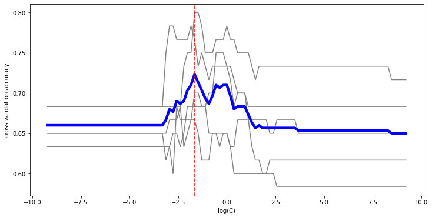

```python
fig, ax = plt.subplots(figsize=(12,6))

ax.plot(np.log(lasso_tune_results.Cs_), lasso_tune_results.scores_[1.0].T, color='grey')
ax.plot(np.log(lasso_tune_results.Cs_), lasso_tune_results.scores_[1.0].mean(axis=0), color='blue', linewidth=4.5)
ax.axvline(x = np.log(lasso_tune_results.C_), color='red', linestyle='dashed')
ax.set_xlabel('log(C)')
ax.set_ylabel('cross validation accuracy')

plt.show()
```

What are the coefficients for the best model?

```python
### to check remember the intercept has been forced to be zero because we are using one hot encoding
print( lasso_tune_results.intercept_ )
```

```
[0.]
```

```python
print( lasso_tune_results.coef_ )
```

```
[[ 0.         -0.0512059   0.         -0.48008568  0.          0.
  -0.33367101 -0.16812191  0.         -0.07612769  0.          0.
   0.08207914  0.          0.          0.3563387   0.          0.
  -0.72801263  0.          0.          0.          0.28009118  0.
   0.          0.          0.          0.          0.12005083 -0.03121948
   0.          0.          0.          0.         -0.15807702  0.
   0.          0.05759473  0.          0.          0.          0.
   0.06756215  0.          0.        ]]
```

Lasso turns off unimportant features. It's simplifying our very complex models!

Which features were turned off?

```python
pd.DataFrame({'MLE': list(sk_mle.coef_.ravel()),
             'ridge_best': list(ridge_tune_results.coef_.ravel()),
             'lasso_best': list(lasso_tune_results.coef_.ravel())},
            index=X_check.columns)
```

|  | MLE | ridge_best | lasso_best |
| --- | --- | --- | --- |
| x5[a] | 0.745668 | 0.002699 | 0.000000 |
| x5[b] | -0.385047 | -0.119318 | -0.051206 |
| x5[c] | 1.203648 | 0.069023 | 0.000000 |
| np.power(x1, 2) | -1.074234 | -0.316275 | -0.480086 |
| x5[T.b]:np.power(x1, 2) | 0.402282 | -0.105644 | 0.000000 |
| x5[T.c]:np.power(x1, 2) | -0.509662 | -0.040491 | 0.000000 |
| np.power(x2, 2) | -0.835028 | -0.223389 | -0.333671 |
| x5[T.b]:np.power(x2, 2) | -0.110721 | -0.144382 | -0.168122 |
| x5[T.c]:np.power(x2, 2) | 0.060735 | -0.048437 | 0.000000 |
| np.power(x3, 2) | -0.271293 | -0.114308 | -0.076128 |
| x5[T.b]:np.power(x3, 2) | 0.284556 | 0.002292 | 0.000000 |
| x5[T.c]:np.power(x3, 2) | -0.031358 | 0.030073 | 0.000000 |
| np.power(x4, 2) | 0.180082 | 0.087521 | 0.082079 |
| x5[T.b]:np.power(x4, 2) | -0.000202 | -0.016412 | 0.000000 |
| x5[T.c]:np.power(x4, 2) | -0.246894 | -0.036330 | 0.000000 |
| x1 | 0.550777 | 0.194261 | 0.356339 |
| x5[T.b]:x1 | 0.357599 | 0.039084 | 0.000000 |
| x5[T.c]:x1 | 0.401345 | 0.118039 | 0.000000 |
| x2 | -1.344532 | -0.359277 | -0.728013 |
| x5[T.b]:x2 | -0.039029 | -0.091612 | 0.000000 |
| x5[T.c]:x2 | 0.091337 | -0.136767 | 0.000000 |
| x3 | -0.074240 | 0.069737 | 0.000000 |
| x5[T.b]:x3 | 0.980028 | 0.159384 | 0.280091 |
| x5[T.c]:x3 | -0.348396 | -0.040015 | 0.000000 |
| x4 | -0.207508 | -0.000842 | 0.000000 |
| x5[T.b]:x4 | 0.308017 | -0.022537 | 0.000000 |
| x5[T.c]:x4 | 0.375018 | 0.040221 | 0.000000 |
| x1:x2 | -0.637185 | -0.040639 | 0.000000 |
| x5[T.b]:x1:x2 | 1.589852 | 0.109268 | 0.120051 |
| x5[T.c]:x1:x2 | -0.841631 | -0.107775 | -0.031219 |
| x1:x3 | -0.228125 | -0.005096 | 0.000000 |
| x5[T.b]:x1:x3 | -0.076567 | -0.009920 | 0.000000 |
| x5[T.c]:x1:x3 | 1.100243 | 0.057836 | 0.000000 |
| x1:x4 | 0.267579 | -0.011382 | 0.000000 |
| x5[T.b]:x1:x4 | -0.768438 | -0.116904 | -0.158077 |
| x5[T.c]:x1:x4 | 0.534747 | 0.038672 | 0.000000 |
| x2:x3 | -0.321794 | 0.058229 | 0.000000 |
| x5[T.b]:x2:x3 | 1.038000 | 0.084754 | 0.057595 |
| x5[T.c]:x2:x3 | 0.338824 | -0.054816 | 0.000000 |
| x2:x4 | -0.153259 | -0.018092 | 0.000000 |
| x5[T.b]:x2:x4 | 0.306935 | -0.005829 | 0.000000 |
| x5[T.c]:x2:x4 | -0.120948 | -0.009786 | 0.000000 |
| x3:x4 | 0.098592 | 0.088090 | 0.067562 |
| x5[T.b]:x3:x4 | -0.206986 | -0.029461 | 0.000000 |
| x5[T.c]:x3:x4 | 0.068941 | 0.068861 | 0.000000 |

## Coefficient paths

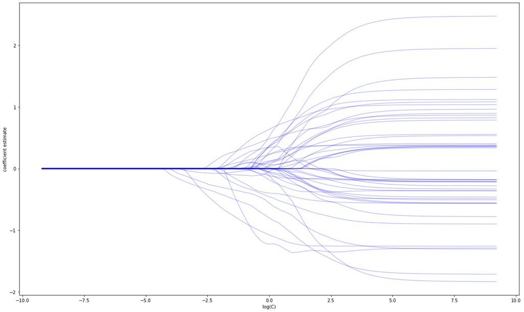

```python
fig, ax = plt.subplots(figsize=(20,12))

ax.plot(np.log(lasso_tune_results.Cs_), lasso_tune_results.coefs_paths_[1.0][1, :, :], 'b-', alpha=0.25)
ax.set_xlabel('log(C)')
ax.set_ylabel('coefficient estimate')

plt.show()
```

## Stratified K-Cross-Validation

```python
from sklearn.model_selection import StratifiedKFold
```

```python
k05_stratify = StratifiedKFold(n_splits=5, shuffle=True, random_state=101)
```

```python
lasso_tune_stratify = LogisticRegressionCV(penalty='l1', Cs=101, cv=k05_stratify, random_state=101, solver='saga', max_iter=5001, fit_intercept=False).fit(X_sk, y_sk.ravel())
```

```python
lasso_tune_stratify.C_
```

```
array([0.22908677])
```

```python
lasso_tune_results.C_
```

```
array([0.19054607])
```

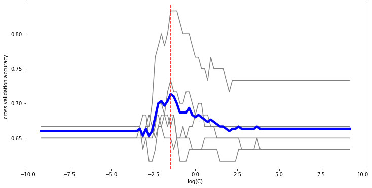

```python
fig, ax = plt.subplots(figsize=(12,6))

ax.plot(np.log(lasso_tune_stratify.Cs_), lasso_tune_stratify.scores_[1.0].T, color='grey')
ax.plot(np.log(lasso_tune_stratify.Cs_), lasso_tune_stratify.scores_[1.0].mean(axis=0), color='blue', linewidth=4.5)
ax.axvline(x = np.log(lasso_tune_stratify.C_), color='red', linestyle='dashed')
ax.set_xlabel('log(C)')
ax.set_ylabel('cross validation accuracy')

plt.show()
```

## Repeated Cross-Validation

```python
from sklearn.model_selection import RepeatedStratifiedKFold
```

```python
k05_rep_stratify = RepeatedStratifiedKFold(n_splits=5, n_repeats = 3, random_state=101)
```

```python
lasso_cv_rep_stratify = LogisticRegressionCV(penalty='l1', Cs=101, cv=k05_rep_stratify, random_state=101, solver='saga', max_iter=5001, fit_intercept=False).fit(X_sk, y_sk.ravel())
```

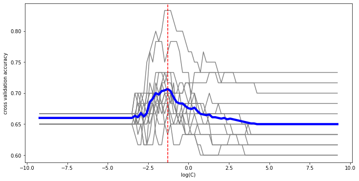

```python
fig, ax = plt.subplots(figsize=(12,6))

ax.plot(np.log(lasso_cv_rep_stratify.Cs_), lasso_cv_rep_stratify.scores_[1.0].T, color='grey')
ax.plot(np.log(lasso_cv_rep_stratify.Cs_), lasso_cv_rep_stratify.scores_[1.0].mean(axis=0), color='blue', linewidth=4.5)
ax.axvline(x = np.log(lasso_cv_rep_stratify.C_), color='red', linestyle='dashed')
ax.set_xlabel('log(C)')
ax.set_ylabel('cross validation accuracy')

plt.show()
```

Visualize the standard error on the performance.

```python
resample_names = ['R' + str(x).zfill(2) for x in range(lasso_cv_rep_stratify.scores_[1.0].T.shape[1])]
cv_df = pd.DataFrame(lasso_cv_rep_stratify.scores_[1.0].T,
                    columns=resample_names)

cv_df['log_C'] = pd.Series(np.log(lasso_cv_rep_stratify.Cs_), index=cv_df.index)
```

```python
cv_lf = cv_df.melt(id_vars=['log_C'], value_vars=resample_names, ignore_index=True)
```

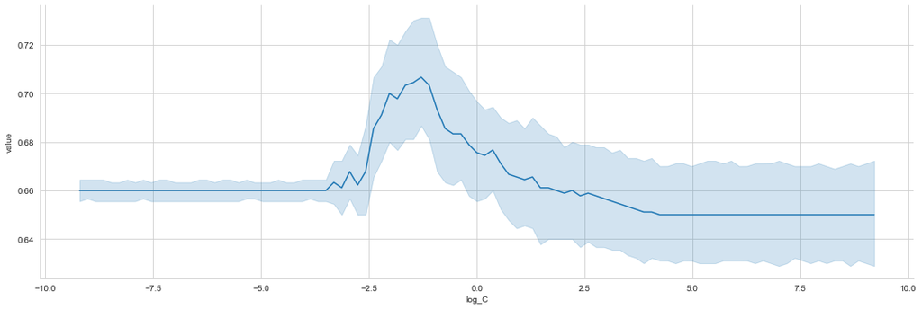

```python
sns.set_style('whitegrid')

sns.relplot(data = cv_lf, x='log_C', y='value', kind='line', aspect=3)

plt.show()
```

Or we can show just 1 standard error around the average.

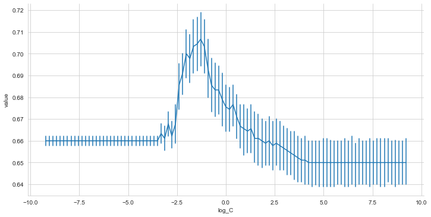

```python
sns.relplot(data = cv_lf, x='log_C', y='value', kind='line', err_style='bars', ci=68, aspect=2)

plt.show()
```

## Elastic net

It's a balance or mixture between ridge and lasso.

## Regression regularization methods

LassoCV and RidgeCV and ElasticNetCV